# WeRateDogs Act Report

[figure not shown]

## Introduction

Raw data must be cleaned and transformed prior to analysis, which typically includes reformatting data, making data modifications, and combining data sets to enhance data. I utilized the tweet archive of Twitter user @dog rates, commonly known as WeRateDogs, for my dataset. WeRateDogs is a Twitter account that scores people's pets and includes a funny comment about the dog. The WeRateDogs Twitter archive includes basic tweet data for all of their 5000+ tweets, but not everything. The archive did not include the retweet and favorite counts for each tweet, so I had to obtain this additional data from the twitter account using the archive's tweet ID.

I also obtained an image predictions file from Udacity servers that had the top three predictions for dog breeds based on images from Twitter. After cleaning the data, I analyzed and visualized the data, the results of which are presented below.

## Correlation between Retweets and Favorites

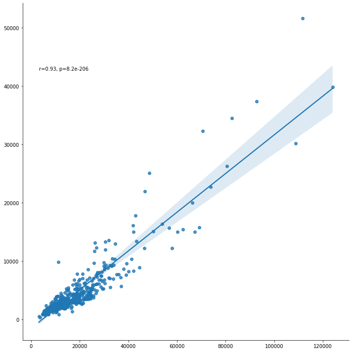

## High Ratings

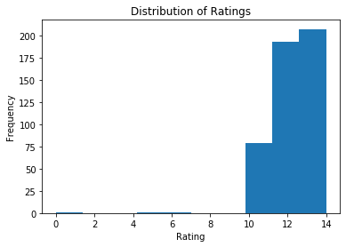

## The most rated dog breed

The black and tan coonhound received the highest mean rating of 14.0, indicating that it was highly ranked among the breeds.

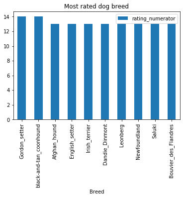

## Top 10 dog breeds by tweet count and favorite count

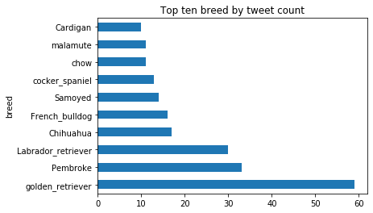

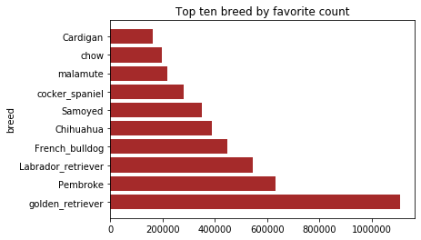

## Because people adore golden retrievers! I'd like to dig more into it and see how it evolves and changes through time.

The amount of golden retriever tweets varied by month, with December and November having the most and April having the fewest. The most tweets for golden retrievers were in 2017, and they were generally high in volume on Mondays and Sundays. So if any paid advertising was to be done, Mondays and Sundays would be a good time.

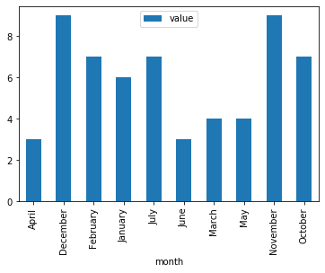

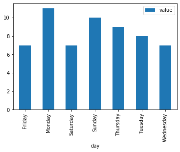

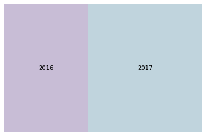

## Where were all these tweets sents from

We can observe that the majority of tweets on golden retrievers are sent from an iPhone.

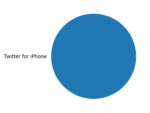